# Puppy Breed Analysis

### > Q100

**Q100: Have you ever considered finding your dog a different home, for any reason? (This does not mean that you did so, just that you considered it.)**

2001 non-empty/NA responses out of 2001 possible responses ( 100 %)

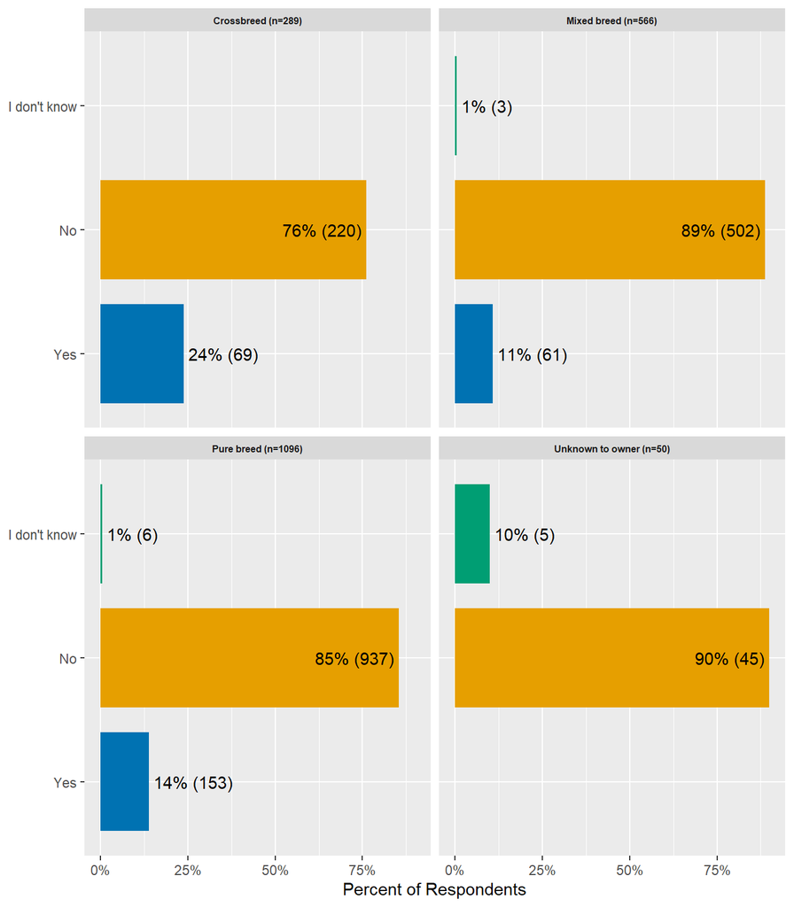

### > Q101

**Which of the following are or were causing to you consider rehoming your dog?**

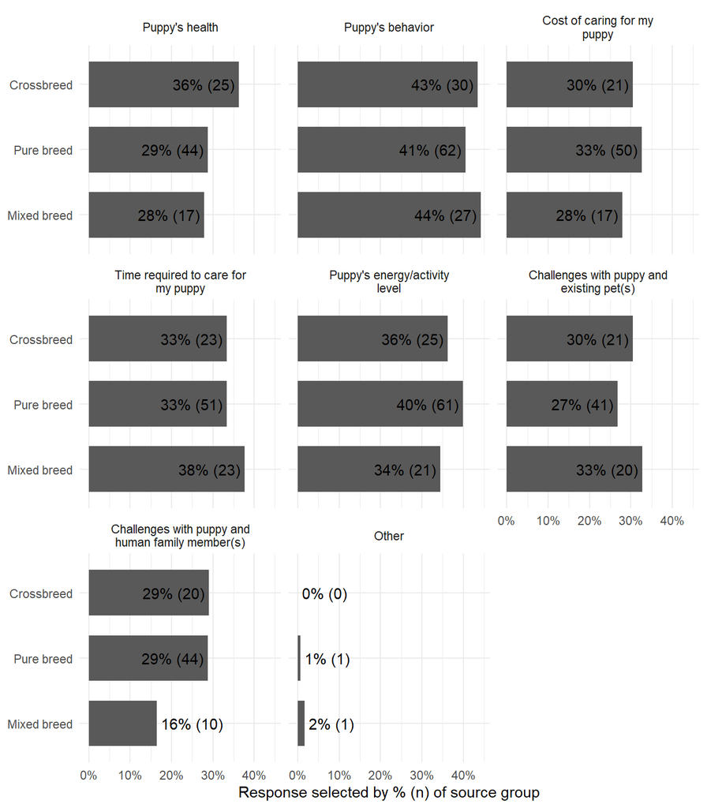

## Q102a

**Q102a: Which state do you live in?**

4002 non-empty/NA responses out of 4002 possible responses ( 100 %)

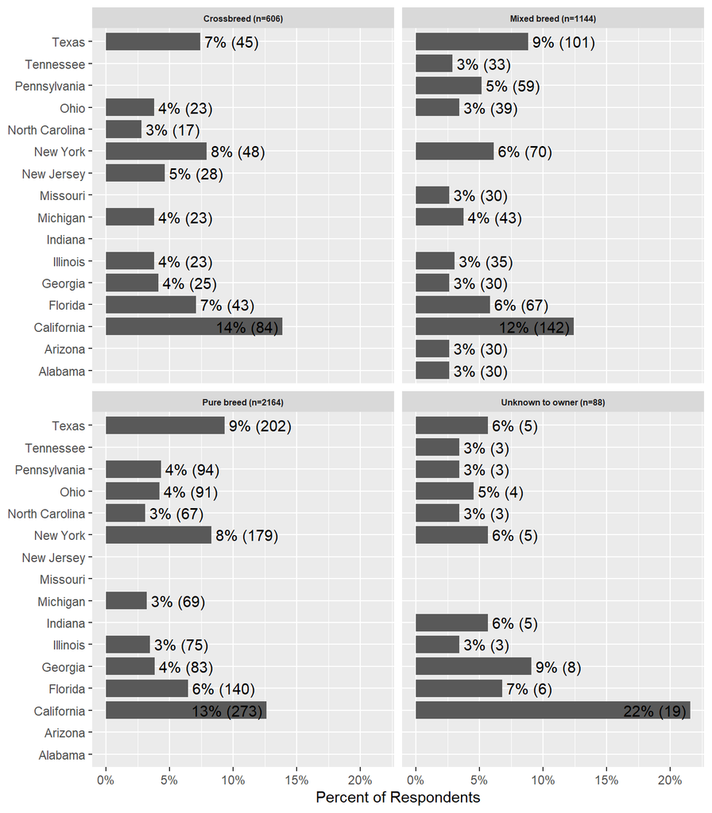

## REGION

**REGION: Hidden region assignment**

4002 non-empty/NA responses out of 4002 possible responses ( 100 %)

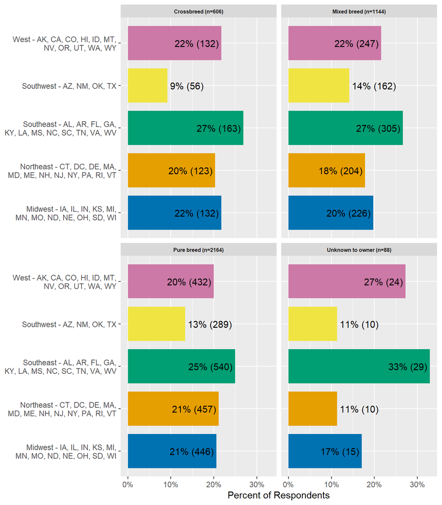

## Q102b - zip code

**excluded because there are too many values to show usefully**

## Q104

**Q104: What is the highest level of school you completed?**

4002 non-empty/NA responses out of 4002 possible responses ( 100 %)

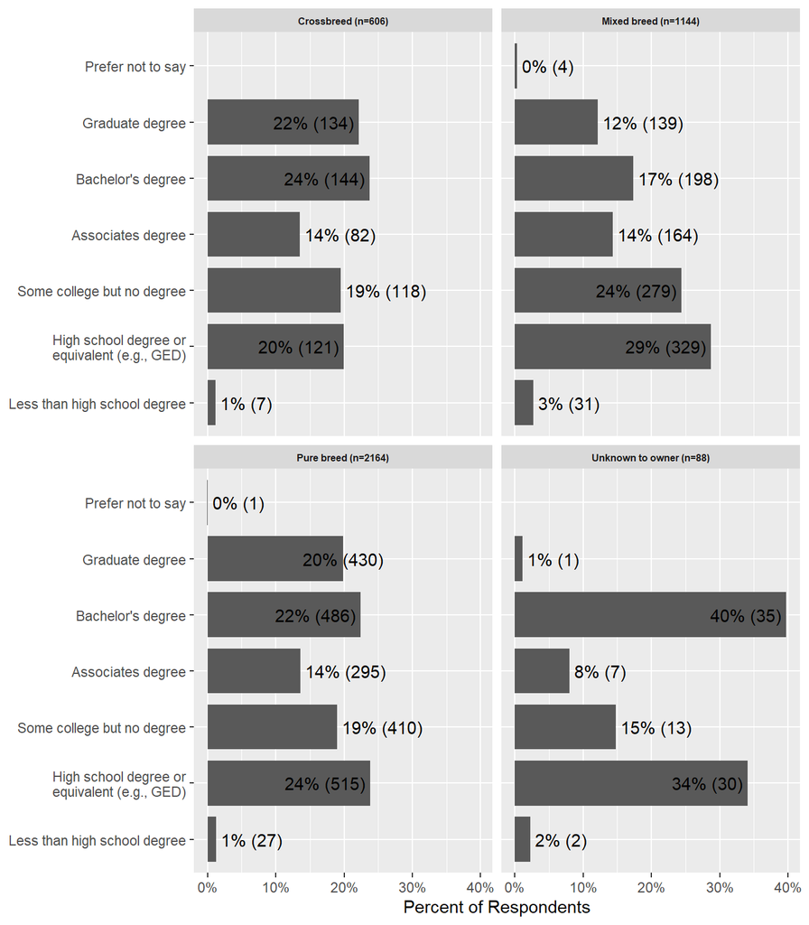

## Q105

**Q105: What is your total annual household income?**

4002 non-empty/NA responses out of 4002 possible responses ( 100 %)

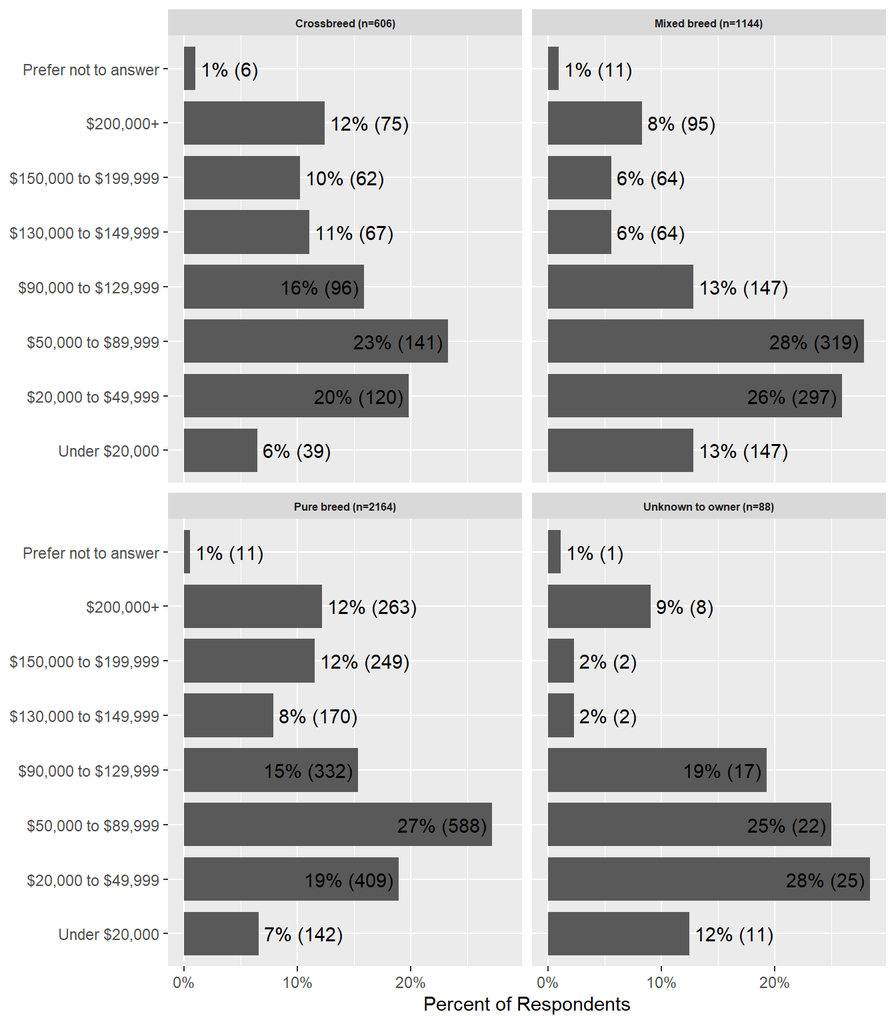

## Q107

**Q107: How would you describe yourself?**

4002 non-empty/NA responses out of 4002 possible responses ( 100 %)

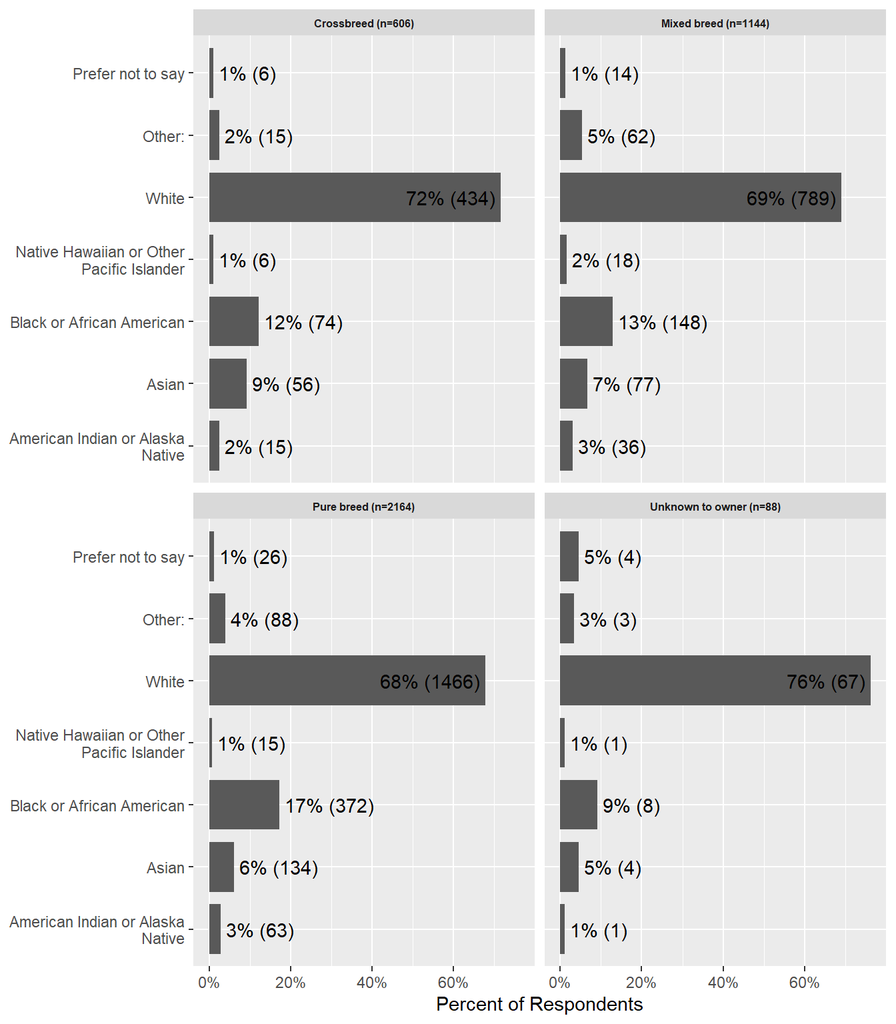

## Q108

**Q108: Do you own or rent your home?**

4002 non-empty/NA responses out of 4002 possible responses ( 100 %)

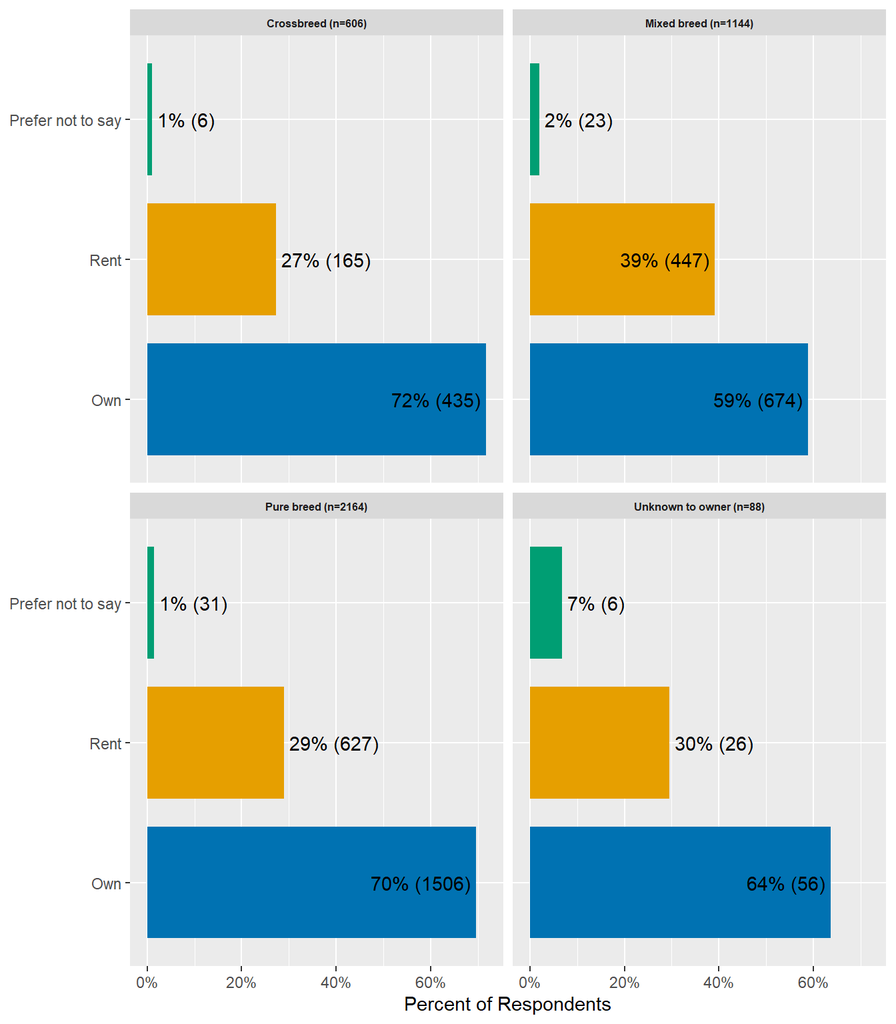